# Introduction to Text Processing

Social and Cultural Analytics (7AAVBCS5)

Dr Mark J. Hill · mark.j.hill@kcl.ac.uk

2026-11-30

## Lecture Plan

- **Introduction**
  - Quick review — the analytical pipeline
  - The summative
- **Part I: Introduction to NLP**
- **Part II: The NLP Pipeline**
  - Pre-processing, tokenisation, lemmatisation, information extraction
- **Part III: spaCy**
- **Part IV: Live Coding**

**Key Learning Outcomes**

By the end of this week you will be able to:

- Understand what NLP is and why it matters for cultural analytics
- Describe the typical NLP processing pipeline
- Pre-process text (lower-casing, stop-word removal)
- Tokenise text, and understand types vs tokens
- Create and analyse word frequency lists in Python
- Apply text processing to research questions

## The analysis process

| Stage | What you are doing | Tools |
| --- | --- | --- |
| **Inspect** | what is the data, what does it contain and represent? | `read_csv`, `type`, `head`, `shape`, `info` |
| **Summarise** | min, mean, median, max, IQR | `describe` |
| **Process** | fix what needs fixing | `dropna`, `fillna`, `astype("category")` |
| **Descriptive** | the shape of the data | `value_counts`, `crosstab`, `groupby` |
| **Analysis** | test ideas, look for relationships | `corr`, `scatter`, `bar`, `hist` |

You may need to go back to processing. Nobody does this in one pass.

# The Summative

## Purpose and scope

**Purpose**

- You are designing and carrying out a data analysis project in a domain of your choice
- It must sit within **digital culture and society** — not generic data science, finance or marketing
- Not a traditional essay
- You are writing for an informed community of analysts, not an academic journal

**Scope and flexibility**

- You can change your project from the **data overview** — that was formative
- Last year’s examples are useful only for structure and technical style

Not a technical tutorial — but your code must be understandable and justified.

## Format

- A short report: **3,500 words** (±15%), **code included in the word count**
- Due **21 January 2027**
- Must be generated automatically from a **notebook** — no screenshots of code
- Include all code in the notebook
- The only editing allowed after export is adding the cover sheet

## Structure

**Introduction** — objectives and research questions; 1–2 paragraphs of background; 5–10 references; situate in digital culture/society

**Data** — what datasets, why they fit your questions, how you accessed them

**Analysis** — the steps, aligned with your research questions. Code correct and **interpreted in the text**. Fine if not all questions are answerable — justify why

**Results & interpretation** — findings in relation to your questions; who benefits, and what the analysis reveals about digital culture/society; **include limitations**

**Conclusion** — what you did, how you analysed it, what the results show. Future work optional

## Assessment criteria

You must demonstrate that:

1. The use case is clearly described and connected to digital culture/society
2. Research questions/objectives are explicit
3. Datasets are appropriate, clearly described, and properly accessed
4. Analysis is relevant to the questions and clearly presented
5. Code is correct, integrated, and explained in the text
6. Interpretation is strong — what do the results mean?
7. Impact is articulated — who benefits and why?
8. Limitations are acknowledged where relevant

Points 3, 6 and 8 map onto the chapter’s §5.2, §5.4 and §5.5. The data overview was a rehearsal for point 3.

# Part I: Introduction to NLP

## What is Natural Language Processing?

The use of computational techniques to analyse natural language, written and spoken, at scale.

- **Computational:** text turned into digital (numeric) representations, to assess relationships between words, often statistically
- **Natural:** language as humans express it — speeches, social media posts, literature, song lyrics
- **Scale:** beyond a single text, to a million books

**Related terms you may have heard**

computational linguistics · text mining · language technology · digital humanities · computational humanities · distant reading · quantitative text analysis · large language models

## The scale problem

**The challenge:** mass digitisation of analogue resources held in libraries and archives, plus ever-growing amounts of born-digital text — web, social media, user-generated content.

**The result:** large textual collections, too big to be read by humans.

**The opportunity:** huge potential in exploring those collections.

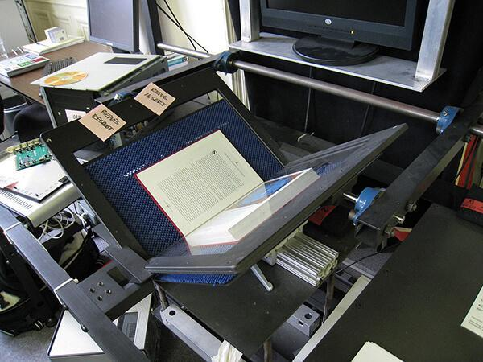

## Why NLP matters for cultural analytics

**Traditional humanities**

- Close reading of individual texts
- Deep interpretation
- Limited scale

**Computational humanities**

- Distant reading of large corpora
- Pattern detection
- Massive scale
- New research questions

**Example questions**

- How has vocabulary changed over time?
- What topics appear in millions of posts?
- How do different authors use language?
- What is the difference in sentiment between authors?
- What words collocate with a concept?

# Part II: The NLP Pipeline

## A typical NLP pipeline

```
Pre-processing → Tokenisation → Lemmatisation → Morphological tagging
   → Part-of-speech tagging → Syntactic parsing → Information extraction → Analysis
```

Each step makes the next possible, and each one throws something away.

## Pre-processing

- Language detection
- **Segmentation**
- Compound splitting
- Punctuation removal
- **Lower-casing**
- **Stop-word removal**
- Spelling standardisation

**Language detection** — multiple languages affect everything downstream, and matter especially for social media data. Prevents mixing incompatible vocabularies and models.

**Segmentation** — splitting text into units of analysis: sentences, tokens, paragraphs, chapters, acts of a play. **The unit of analysis decision belongs to the researcher.**

**Compound splitting** — `notebook` → `note` + `book`. Rare for English, important for morphologically rich languages.

## Lower-casing, punctuation, stop words

```python
text = "Alice was beginning to get very tired of sitting by her sister on the bank."
print(text.lower())
```

```
alice was beginning to get very tired of sitting by her sister on the bank.
```

- **Punctuation removal** strips marks that do not carry meaning for your question
- **Lower-casing** avoids treating `The` and `the` as different words
- **Stop-word removal** drops very common function words — “the”, “and”, “of”

Every one of these throws information away. Lower-casing loses the distinction between `US` and `us`; stop-word removal loses pronouns and negation.

## Tokenisation

Splitting text into **tokens** — usually words, but the boundaries are a decision.

```python
import spacy

nlp = spacy.load("en_core_web_sm")
doc = nlp("Alice wasn't expecting the White Rabbit's waistcoat-pocket.")
print([t.text for t in doc])
```

```
['Alice', 'was', "n't", 'expecting', 'the', 'White', 'Rabbit', "'s", 'waistcoat', '-', 'pocket', '.']
```

## Types and tokens

```python
tokens = [t.text.lower() for t in doc if t.is_alpha]
print("tokens:", len(tokens))
print("types :", len(set(tokens)))
```

```
tokens: 8
types : 8
```

- **Tokens** — every occurrence
- **Types** — every distinct word

The ratio between them is one of the oldest measures in the field.

## Lemmatisation

```python
doc = nlp("The rabbits were running and had run before.")
for t in doc:
    if t.is_alpha:
        print(f"  {t.text:10} -> {t.lemma_}")
```

```
  The        -> the
  rabbits    -> rabbit
  were       -> be
  running    -> run
  and        -> and
  had        -> have
  run        -> run
  before     -> before
```

Reduces words to their dictionary form, so `running`, `ran` and `run` count as one thing.

## Part-of-speech tagging

```python
doc = nlp("The Queen of Hearts painted the roses red.")
for t in doc:
    print(f"  {t.text:10} {t.pos_:6} {spacy.explain(t.pos_)}")
```

```
  The        DET    determiner
  Queen      NOUN   noun
  of         ADP    adposition
  Hearts     PROPN  proper noun
  painted    VERB   verb
  the        DET    determiner
  roses      NOUN   noun
  red        VERB   verb
  .          PUNCT  punctuation
```

## Syntactic parsing and information extraction

```python
doc = nlp("President Wilson addressed Congress in Washington in 1917.")
print("entities:", [(e.text, e.label_) for e in doc.ents])
```

```
entities: [('Wilson', 'PERSON'), ('Congress', 'ORG'), ('Washington', 'GPE'), ('1917', 'DATE')]
```

**Typical information-extraction tasks:** named entity recognition, relation extraction, event detection, collocation.

## Interpretation is key

Every stage of the pipeline is a choice, and every choice removes something.

- Lower-casing removes the difference between `US` and `us`
- Stop-word removal removes pronouns, and **negation**
- Lemmatisation removes tense and number
- Tokenisation decides what counts as a word

Hill, “Contextual Analytics”, §5.3 — representation choices determine which distinctions remain visible and which are suppressed.

# Part III: spaCy

## spaCy

An NLP library that does the whole pipeline in one call.

```python
import spacy
nlp = spacy.load("en_core_web_sm")
doc = nlp(text)
```

- `nlp` is the **model** — a trained pipeline for a language
- `doc` is the **annotated text** — every token, with its lemma, part of speech, and more
- The model is already installed for you; if not, see the module README

## From doc to data frame

```python
import pandas as pd

doc = nlp("Alice was beginning to get very tired of sitting by her sister.")
tokens = pd.DataFrame([
    {"token": t.text, "lemma": t.lemma_, "pos": t.pos_, "is_stop": t.is_stop}
    for t in doc if t.is_alpha
])
tokens.head(8)
```

|  | token | lemma | pos | is_stop |
| --- | --- | --- | --- | --- |
| 0 | Alice | Alice | PROPN | False |
| 1 | was | be | AUX | True |
| 2 | beginning | begin | VERB | False |
| 3 | to | to | PART | True |
| 4 | get | get | VERB | True |
| 5 | very | very | ADV | True |
| 6 | tired | tired | ADJ | False |
| 7 | of | of | ADP | True |

Once it is a data frame, everything from Weeks 3 to 8 applies again.

## Word frequencies

```python
from pathlib import Path

alice = Path("../../data/alice.txt").read_text(encoding="utf-8", errors="replace")
doc = nlp(alice[:200_000])

words = pd.Series([t.lemma_.lower() for t in doc if t.is_alpha and not t.is_stop])
words.value_counts().head(10)
```

```
say       481
alice     396
think     134
go        129
little    128
know      107
look      106
begin      93
like       92
come       91
Name: count, dtype: int64
```

# Part IV: Live Coding

## Live coding

1. Load a text, annotate it with spaCy
2. Tokens, lemmas, parts of speech into a data frame
3. Word frequencies, before and after removing stop words
4. Named entities
5. Loop over the corpus — the Week 9 pattern, applied to text

## Before next week

1. Complete `w10_worksheet.ipynb` in the workshop
2. Read Hill, “Contextual Analytics”, §5.3
3. **Work on your report** — it is due 21 January

**Note**

The quiz in next week’s lecture covers **this week’s** material, and is the **last one**.

## Debugging with AI

NLP code fails in a particular way: it runs, and gives you a list of things that are subtly wrong — tokens split oddly, lemmas that are not lemmas, entities that are not entities.

Ask https://ai.create.kcl.ac.uk/chat to explain **what a pipeline stage does to your text**, then check its answer against your own output. Do not ask it to interpret your results — that is the part you are being assessed on.